# Credit Card Approval Prediction

## Members: Sreeja Macha, Colin Chen, Jessica Yang

# 1. Exploratory Data Analysis

```python
# Import all the necessary libraries
import numpy as np
import pandas as pd
import matplotlib.pyplot as plt
import lightgbm as lgb
import xgboost as xgb
from sklearn.model_selection import train_test_split, RandomizedSearchCV
from imblearn.over_sampling import SMOTE, BorderlineSMOTE, ADASYN
from sklearn.ensemble import RandomForestClassifier, GradientBoostingClassifier
from sklearn.metrics import classification_report, mean_squared_error, r2_score, accuracy_score, confusion_matrix, precision_recall_curve, auc
from sklearn.preprocessing import OneHotEncoder
from sklearn.compose import ColumnTransformer
from scipy.stats import randint, norm
from sklearn.inspection import permutation_importance
from sklearn.utils import shuffle
```

```python
# Load the datasets
application_record_df = pd.read_csv("application_record.csv")
credit_record_df = pd.read_csv("credit_record.csv")
```

```python
# Display the first 5 application records
application_record_df.head(5)
```

|  | ID | CODE_GENDER | FLAG_OWN_CAR | FLAG_OWN_REALTY | CNT_CHILDREN | AMT_INCOME_TOTAL | NAME_INCOME_TYPE | NAME_EDUCATION_TYPE | NAME_FAMILY_STATUS | NAME_HOUSING_TYPE | DAYS_BIRTH | DAYS_EMPLOYED | FLAG_MOBIL | FLAG_WORK_PHONE | FLAG_PHONE | FLAG_EMAIL | OCCUPATION_TYPE | CNT_FAM_MEMBERS |
| --- | --- | --- | --- | --- | --- | --- | --- | --- | --- | --- | --- | --- | --- | --- | --- | --- | --- | --- |
| 0 | 5008804 | M | Y | Y | 0 | 427500.0 | Working | Higher education | Civil marriage | Rented apartment | -12005 | -4542 | 1 | 1 | 0 | 0 | NaN | 2.0 |
| 1 | 5008805 | M | Y | Y | 0 | 427500.0 | Working | Higher education | Civil marriage | Rented apartment | -12005 | -4542 | 1 | 1 | 0 | 0 | NaN | 2.0 |
| 2 | 5008806 | M | Y | Y | 0 | 112500.0 | Working | Secondary / secondary special | Married | House / apartment | -21474 | -1134 | 1 | 0 | 0 | 0 | Security staff | 2.0 |
| 3 | 5008808 | F | N | Y | 0 | 270000.0 | Commercial associate | Secondary / secondary special | Single / not married | House / apartment | -19110 | -3051 | 1 | 0 | 1 | 1 | Sales staff | 1.0 |
| 4 | 5008809 | F | N | Y | 0 | 270000.0 | Commercial associate | Secondary / secondary special | Single / not married | House / apartment | -19110 | -3051 | 1 | 0 | 1 | 1 | Sales staff | 1.0 |

```python
# Display the columns info of application records
application_record_df.info()
```

```
<class 'pandas.core.frame.DataFrame'>
RangeIndex: 438557 entries, 0 to 438556
Data columns (total 18 columns):
 #   Column               Non-Null Count   Dtype
---  ------               --------------   -----
 0   ID                   438557 non-null  int64
 1   CODE_GENDER          438557 non-null  object
 2   FLAG_OWN_CAR         438557 non-null  object
 3   FLAG_OWN_REALTY      438557 non-null  object
 4   CNT_CHILDREN         438557 non-null  int64
 5   AMT_INCOME_TOTAL     438557 non-null  float64
 6   NAME_INCOME_TYPE     438557 non-null  object
 7   NAME_EDUCATION_TYPE  438557 non-null  object
 8   NAME_FAMILY_STATUS   438557 non-null  object
 9   NAME_HOUSING_TYPE    438557 non-null  object
 10  DAYS_BIRTH           438557 non-null  int64
 11  DAYS_EMPLOYED        438557 non-null  int64
 12  FLAG_MOBIL           438557 non-null  int64
 13  FLAG_WORK_PHONE      438557 non-null  int64
 14  FLAG_PHONE           438557 non-null  int64
 15  FLAG_EMAIL           438557 non-null  int64
 16  OCCUPATION_TYPE      304354 non-null  object
 17  CNT_FAM_MEMBERS      438557 non-null  float64
dtypes: float64(2), int64(8), object(8)
memory usage: 60.2+ MB
```

```python
# Find the # of missing values for each column
missing_values_count = application_record_df.isna().sum()
print(f"\n\nNumber of missing values for each column is:\n{missing_values_count}")
```

```
Number of missing values for each column is:
ID                          0
CODE_GENDER                 0
FLAG_OWN_CAR                0
FLAG_OWN_REALTY             0
CNT_CHILDREN                0
AMT_INCOME_TOTAL            0
NAME_INCOME_TYPE            0
NAME_EDUCATION_TYPE         0
NAME_FAMILY_STATUS          0
NAME_HOUSING_TYPE           0
DAYS_BIRTH                  0
DAYS_EMPLOYED               0
FLAG_MOBIL                  0
FLAG_WORK_PHONE             0
FLAG_PHONE                  0
FLAG_EMAIL                  0
OCCUPATION_TYPE        134203
CNT_FAM_MEMBERS             0
dtype: int64
```

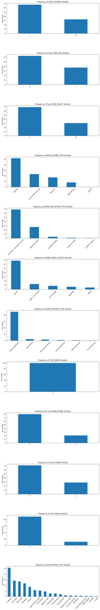

```python
# List of categorical columns
columns = ["CODE_GENDER", "FLAG_OWN_CAR", "FLAG_OWN_REALTY", "NAME_INCOME_TYPE",
           "NAME_EDUCATION_TYPE", "NAME_FAMILY_STATUS", "NAME_HOUSING_TYPE", "FLAG_MOBIL",
           "FLAG_WORK_PHONE", "FLAG_PHONE", "FLAG_EMAIL", "OCCUPATION_TYPE"]

# Set up the matplotlib figure for sorted bar plots
fig, axes = plt.subplots(len(columns), 1, figsize=(10, 5*len(columns)))

# Loop through each specified column to calculate frequencies, sort them, and plot
for i, col in enumerate(columns):
    # Calculate frequency (in percentage) and sort values in descending order
    freq_series = application_record_df[col].value_counts(normalize=True).sort_values(ascending=False) * 100

    # Sort index based on values for plotting
    sorted_index = freq_series.index

    # Plot with sorted values
    ax = freq_series.plot(kind='bar', ax=axes[i], title=f"Frequency of {col} (Sorted)")
    ax.set_ylabel("Percentage")
    ax.set_xticklabels(ax.get_xticklabels(), rotation=45)

    plt.tight_layout()

plt.show()
```

Gender Distribution: The applicant pool exhibits a gender imbalance, which may suggest different borrowing behaviors or financial engagement levels between genders.

Car Ownership: A significant portion of applicants own cars, suggesting a level of financial stability or lifestyle that involves asset accumulation.

Real Estate Ownership: Over half of the applicants own real estate, indicating a probable factor in their creditworthiness due to asset security.

Income Types: A large majority of applicants are employed, with smaller proportions being pensioners or associated with commercial entities. This points to the working population being the primary applicant segment for credit.

Educational Background: The majority of the applicants have completed secondary education or higher, suggesting a correlation between education levels and the likelihood of seeking credit.

Marital Status: Most applicants are married, which could potentially influence their financial liabilities and credit needs.

Housing Type: The vast majority live in a house/apartment, suggesting a stable living situation, which could be favorable for credit approval.

Occupation Type: Laborers and core staff form the largest occupational groups among applicants, potentially reflecting the socioeconomic status of the majority of applicants.

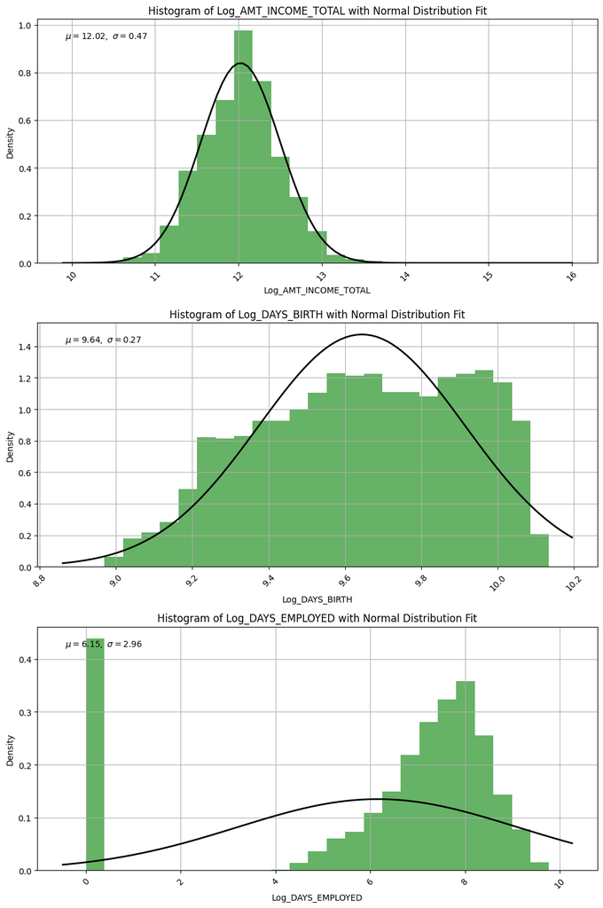

```python
# Take the log of AMT_INCOME_TOTAL
application_record_df['Log_AMT_INCOME_TOTAL'] = np.log(application_record_df['AMT_INCOME_TOTAL'])
# Take the log of DAYS_BIRTH as age (counted by day frequency)
application_record_df['Log_DAYS_BIRTH'] = np.log(np.abs(application_record_df['DAYS_BIRTH']))

# Convert positive values to 0 for DAYS_EMPLOYED
# Data dictionary explanation: Count backwards from current day(0). If positive, it means the person currently unemployed.
application_record_df['DAYS_EMPLOYED'] = application_record_df['DAYS_EMPLOYED'].apply(lambda x: 0 if x > 0 else x)

# Apply log transformation only to non-zero values of DAYS_EMPLOYED, else set to 0
application_record_df['Log_DAYS_EMPLOYED'] = application_record_df['DAYS_EMPLOYED'].apply(lambda x: np.log(-x) if x < 0 else 0)

# Variables to plot
log_variables = ['Log_AMT_INCOME_TOTAL', 'Log_DAYS_BIRTH', 'Log_DAYS_EMPLOYED']

# Set up the matplotlib figure
fig, axes = plt.subplots(len(log_variables), 1, figsize=(10, 5*len(log_variables)))

# Loop through each variable to draw a histogram
for i, var in enumerate(log_variables):
    # Get the data of the variable
    data = application_record_df[var]
    # Plot histogram
    data.hist(bins=25, ax=axes[i], density=True, alpha=0.6, color='g')
    # Calculate normal distribution parameters
    mu, std = norm.fit(data)

    # Draw a normal distribution fitting line
    xmin, xmax = axes[i].get_xlim()
    x = np.linspace(xmin, xmax, 100)
    p = norm.pdf(x, mu, std)
    axes[i].plot(x, p, 'k', linewidth=2)

    # Set the title and label
    title = f'Histogram of {var} with Normal Distribution Fit'
    axes[i].set_title(title)
    axes[i].set_xlabel(var)
    axes[i].set_ylabel('Density')

    # Mark mu and std in the upper left corner of the chart
    textstr = f'$\mu={mu:.2f},\ \sigma={std:.2f}$'
    axes[i].text(0.05, 0.95, textstr, transform=axes[i].transAxes, verticalalignment='top')

for ax in axes:
    ax.set_xticklabels(ax.get_xticklabels(), rotation=45)

plt.tight_layout()
plt.show()
```

- Income levels are log-normally distributed, indicating that while there are high earners, the majority of applicants have income levels around the mean, reflecting a typical workforce.
- The log transformation of employment days indicates moderate job tenure among most applicants, signaling financial stability and repayment ability, though some have shorter or no employment history.
- The age distribution indicates a client base that is young to middle-aged, which generally could mean a longer time in the workforce and potentially lower risk associated with loan repayment over time.

```python
# Display the first 5 credit records
credit_record_df.head(5)
```

|  | ID | MONTHS_BALANCE | STATUS |
| --- | --- | --- | --- |
| 0 | 5001711 | 0 | X |
| 1 | 5001711 | -1 | 0 |
| 2 | 5001711 | -2 | 0 |
| 3 | 5001711 | -3 | 0 |
| 4 | 5001712 | 0 | C |

```python
# Find the # of missing values for each column
missing_values_count = credit_record_df.isna().sum()
print(f"\n\nNumber of missing values for each column is:\n{missing_values_count}")
```

```
Number of missing values for each column is:
ID                0
MONTHS_BALANCE    0
STATUS            0
dtype: int64
```

```python
# Compute 'WINDOW' for each Client
credit_record_df['WINDOW'] = credit_record_df.groupby('ID')['MONTHS_BALANCE'].transform('min').abs()

# Compute 'MONTHS_ON_BOOK' for each client record
# It is the number of months that an account has been active upto the current record month
credit_record_df['MONTHS_ON_BOOK'] = credit_record_df['WINDOW'] - credit_record_df['MONTHS_BALANCE'].abs()

# Display the first 5 credit records
credit_record_df.head(5)
```

|  | ID | MONTHS_BALANCE | STATUS | WINDOW | MONTHS_ON_BOOK |
| --- | --- | --- | --- | --- | --- |
| 0 | 5001711 | 0 | X | 3 | 3 |
| 1 | 5001711 | -1 | 0 | 3 | 2 |
| 2 | 5001711 | -2 | 0 | 3 | 1 |
| 3 | 5001711 | -3 | 0 | 3 | 0 |
| 4 | 5001712 | 0 | C | 18 | 18 |

```
0     370
1     686
2     771
3     919
4     874
     ...
56    470
57    400
58    440
59    406
60    415
Name: WINDOW, Length: 61, dtype: int64
```

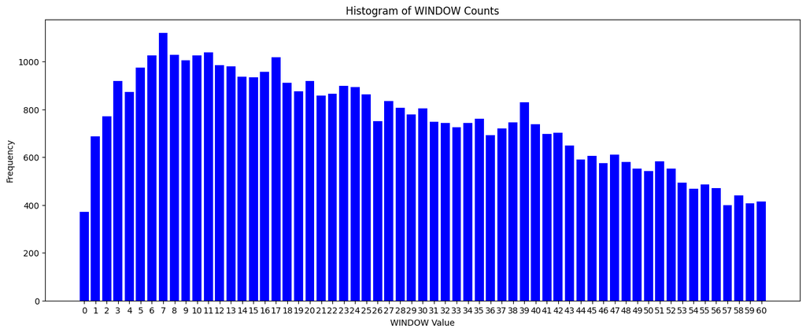

```python
# # Drop duplicate IDs, keeping only the first occurrence
unique_credit_records = credit_record_df.drop_duplicates(subset='ID', keep='first')
pd.reset_option('display.max_rows')
window_counts = unique_credit_records['WINDOW'].value_counts().sort_index()
print(window_counts)

# Plot the histogram of the 'WINDOW' column for unique IDs
plt.figure(figsize=(16,6))
plt.bar(window_counts.index, window_counts.values, color='blue')
plt.title('Histogram of WINDOW Counts')
plt.xlabel('WINDOW Value')
plt.ylabel('Frequency')
plt.xticks(range(0, max(window_counts.index)+1))  # Set x-ticks if needed
plt.show()
```

The distribution is relatively uniform across a range of values, suggesting that the clients' credit activity spans a variety of timeframes. There's a gradual decline in frequency as the window value increases, indicating fewer clients with longer credit histories.

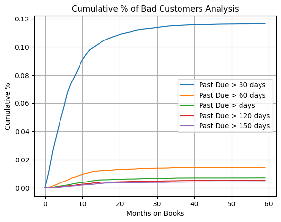

```python
# Computes the cumulative percentage of bad customers based on different past due periods
def calculate_observe(credit, command):
    '''Calculate Observe Window'''

    id_sum = len(set(credit_record_df['ID']))
    credit_record_df['TEMP_STATUS'] = 0

    exec(command)

    minagg = credit_record_df[credit_record_df['TEMP_STATUS'] == 1].groupby('ID')['MONTHS_ON_BOOK'].min()
    minagg = pd.DataFrame(minagg)
    minagg['ID'] = minagg.index
    result_df = pd.DataFrame({'MONTHS_ON_BOOK':range(0,credit_record_df['WINDOW'].max()), 'rate': None})
    due_list = []
    for i in range(0,61):
        due = minagg[minagg['MONTHS_ON_BOOK']  == i]['ID']
        due_list.extend(due)
        result_df.loc[result_df['MONTHS_ON_BOOK'] == i, 'rate'] = len(set(due_list)) / id_sum
    return result_df['rate']

commands = [
    "credit_record_df.loc[credit_record_df['STATUS'].isin(['1', '2', '3', '4', '5']), 'TEMP_STATUS'] = 1",
    "credit_record_df.loc[credit_record_df['STATUS'].isin(['2', '3', '4', '5']), 'TEMP_STATUS'] = 1",
    "credit_record_df.loc[credit_record_df['STATUS'].isin(['3', '4', '5']), 'TEMP_STATUS'] = 1",
    "credit_record_df.loc[credit_record_df['STATUS'].isin(['4', '5']), 'TEMP_STATUS'] = 1",
    "credit_record_df.loc[credit_record_df['STATUS'] == '5', 'TEMP_STATUS'] = 1"
]

over30Days = calculate_observe(credit_record_df, commands[0])
over60Days = calculate_observe(credit_record_df, commands[1])
over90Days = calculate_observe(credit_record_df, commands[2])
over120Days = calculate_observe(credit_record_df, commands[3])
over150Days = calculate_observe(credit_record_df, commands[4])

# Plot the cumulative % of bad customers
window_list = pd.DataFrame({'Past Due > 30 days': over30Days,
                       'Past Due > 60 days': over60Days,
                       'Past Due > days': over90Days,
                       'Past Due > 120 days': over120Days,
                       'Past Due > 150 days': over150Days
                        })

window_list.plot(grid = True, title = 'Cumulative % of Bad Customers Analysis')
plt.xlabel('Months on Books')
plt.ylabel('Cumulative %')
plt.show()

# Drop 'TEMP_STATUS' column
credit_record_df.drop(columns=['TEMP_STATUS'], inplace=True)
```

- Low Percentage of Bad Debt: The purple line is close to the bottom of the graph, which indicates that the percentage of loans categorized as bad debt (>150 days past due) is very low relative to the total loan portfolio.
- Stable After Initial Period: There is an initial rise in the cumulative percentage as the months on books increase, but the line appears to flatten out after about 15 months. This suggests that most of the loans that become bad debt do so relatively around this period, and after a certain point, the likelihood of loans becoming bad debt stabilizes and doesn't increase much.
- Comparative Performance: Compared to loans that are past due more than 30, 60, 90, and 120 days, the loans that are past due more than 150 days represent a much smaller fraction. This indicates that while there are loans that are late, most of them do not reach the threshold of >150 days past due, which would categorize them as bad debt.
- To conclude: A 20-months observe window could cover most bad customers. So, this will the observation window for the analysis.